# ML_Assignment 5

Jacob Joy

```r
library(factoextra)
library(dplyr)
library(dbscan)
library(fpc)
set.seed(123)
#laptop Data Import
#wines = read.csv("C:\\wine-clustering.csv")
#Desktop Data Import
wines = read.csv("F:\\wine-clustering.csv")
```

# Q1-A Explain how normalization and the number of clusters (k) can affect the clustering outcome?

When performing clustering the normalization of data as well as the number of clusters *k* is important in producing acurate outcomes. Clustering depends on the use of a distance metric commonly the euclidean distance, because of this if our data has different scales one variable could over take the others causing our model to not utilize all the relevant information. This leads to clusters that may not represent actual clusters and will only create clusters based on the highest scaled variable. The number of clusters selected will also effect the outcome, accuracy, and meaningfulness of the results. If a small value of clusters *k* is used there may not be enough groups to sort the observations in a proper way, this can lead to lose of important patterns and clusters that should be separate will can end up being merged to fit the value of *k*. On the other hand if to high of a value of *k* is used there may be too many clusters to give any meaning fulling interpretations. A large number for *k* may also result in clusters that should not be split up being broken up into multiple clusters to satisfy our value for *k*. One final issue with a large value of *k* could mean clusters may be formed with too few observations making them not as meaningful.

# Q1-B Code

```r
#Check the structure of the data
str(wines)
```

```
'data.frame':   178 obs. of  13 variables:
 $ Alcohol             : num  14.2 13.2 13.2 14.4 13.2 ...
 $ Malic_Acid          : num  1.71 1.78 2.36 1.95 2.59 1.76 1.87 2.15 1.64 1.35 ...
 $ Ash                 : num  2.43 2.14 2.67 2.5 2.87 2.45 2.45 2.61 2.17 2.27 ...
 $ Ash_Alcanity        : num  15.6 11.2 18.6 16.8 21 15.2 14.6 17.6 14 16 ...
 $ Magnesium           : int  127 100 101 113 118 112 96 121 97 98 ...
 $ Total_Phenols       : num  2.8 2.65 2.8 3.85 2.8 3.27 2.5 2.6 2.8 2.98 ...
 $ Flavanoids          : num  3.06 2.76 3.24 3.49 2.69 3.39 2.52 2.51 2.98 3.15 ...
 $ Nonflavanoid_Phenols: num  0.28 0.26 0.3 0.24 0.39 0.34 0.3 0.31 0.29 0.22 ...
 $ Proanthocyanins     : num  2.29 1.28 2.81 2.18 1.82 1.97 1.98 1.25 1.98 1.85 ...
 $ Color_Intensity     : num  5.64 4.38 5.68 7.8 4.32 6.75 5.25 5.05 5.2 7.22 ...
 $ Hue                 : num  1.04 1.05 1.03 0.86 1.04 1.05 1.02 1.06 1.08 1.01 ...
 $ OD280               : num  3.92 3.4 3.17 3.45 2.93 2.85 3.58 3.58 2.85 3.55 ...
 $ Proline             : int  1065 1050 1185 1480 735 1450 1290 1295 1045 1045 ...
```

```r
#summary check
summary(wines)
```

```
    Alcohol        Malic_Acid         Ash         Ash_Alcanity     Magnesium      Total_Phenols     Flavanoids    Nonflavanoid_Phenols Proanthocyanins
 Min.   :11.03   Min.   :0.740   Min.   :1.360   Min.   :10.60   Min.   : 70.00   Min.   :0.980   Min.   :0.340   Min.   :0.1300       Min.   :0.410
 1st Qu.:12.36   1st Qu.:1.603   1st Qu.:2.210   1st Qu.:17.20   1st Qu.: 88.00   1st Qu.:1.742   1st Qu.:1.205   1st Qu.:0.2700       1st Qu.:1.250
 Median :13.05   Median :1.865   Median :2.360   Median :19.50   Median : 98.00   Median :2.355   Median :2.135   Median :0.3400       Median :1.555
 Mean   :13.00   Mean   :2.336   Mean   :2.367   Mean   :19.49   Mean   : 99.74   Mean   :2.295   Mean   :2.029   Mean   :0.3619       Mean   :1.591
 3rd Qu.:13.68   3rd Qu.:3.083   3rd Qu.:2.558   3rd Qu.:21.50   3rd Qu.:107.00   3rd Qu.:2.800   3rd Qu.:2.875   3rd Qu.:0.4375       3rd Qu.:1.950
 Max.   :14.83   Max.   :5.800   Max.   :3.230   Max.   :30.00   Max.   :162.00   Max.   :3.880   Max.   :5.080   Max.   :0.6600       Max.   :3.580
 Color_Intensity       Hue             OD280          Proline
 Min.   : 1.280   Min.   :0.4800   Min.   :1.270   Min.   : 278.0
 1st Qu.: 3.220   1st Qu.:0.7825   1st Qu.:1.938   1st Qu.: 500.5
 Median : 4.690   Median :0.9650   Median :2.780   Median : 673.5
 Mean   : 5.058   Mean   :0.9574   Mean   :2.612   Mean   : 746.9
 3rd Qu.: 6.200   3rd Qu.:1.1200   3rd Qu.:3.170   3rd Qu.: 985.0
 Max.   :13.000   Max.   :1.7100   Max.   :4.000   Max.   :1680.0
```

```r
#Check for missing values
colMeans(is.na(wines))
```

```
             Alcohol           Malic_Acid                  Ash         Ash_Alcanity            Magnesium        Total_Phenols           Flavanoids
                   0                    0                    0                    0                    0                    0                    0
Nonflavanoid_Phenols      Proanthocyanins      Color_Intensity                  Hue                OD280              Proline
                   0                    0                    0                    0                    0                    0
```

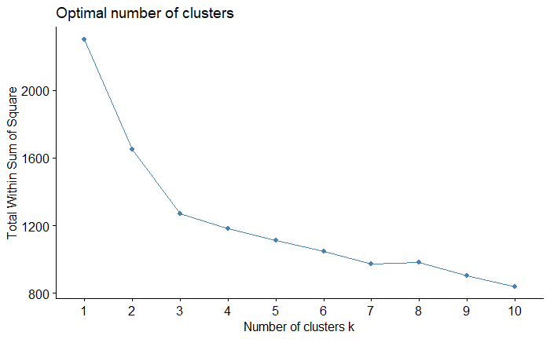

```r
#Normalize data
wines.norm = scale(wines)

#finding a optimal value for k using Elbow Method
fviz_nbclust(wines.norm, kmeans, method = "wss")
```

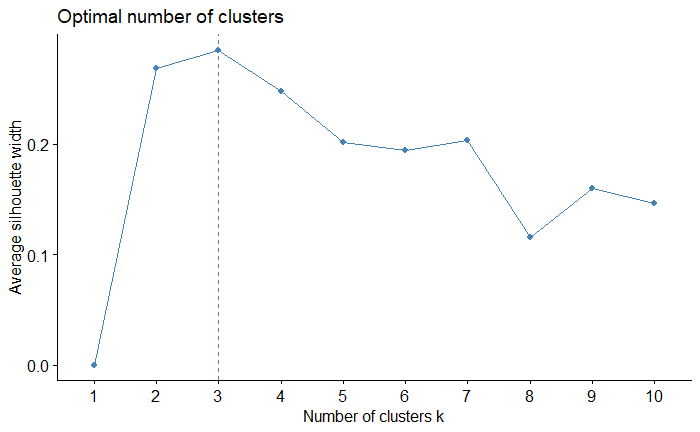

```r
#finding optimal value for k using Silhouette
fviz_nbclust(wines.norm, kmeans, method = "silhouette")
```

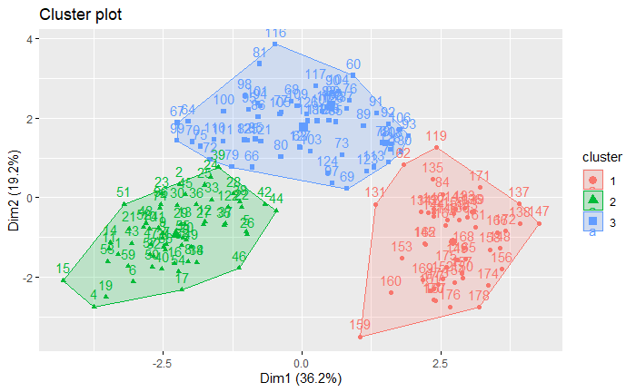

```r
#Performing K means with a k value of 3 based on the elbow point and the peak Silhoutte
k3 = kmeans(wines.norm, centers = 3, nstart = 25)

#Plot of clusters
fviz_cluster(k3, data = wines)
```

```r
#Centers
k3$centers
```

```
     Alcohol Malic_Acid        Ash Ash_Alcanity   Magnesium Total_Phenols  Flavanoids Nonflavanoid_Phenols Proanthocyanins Color_Intensity        Hue
1  0.1644436  0.8690954  0.1863726    0.5228924 -0.07526047   -0.97657548 -1.21182921           0.72402116     -0.77751312       0.9388902 -1.1615122
2  0.8328826 -0.3029551  0.3636801   -0.6084749  0.57596208    0.88274724  0.97506900          -0.56050853      0.57865427       0.1705823  0.4726504
3 -0.9234669 -0.3929331 -0.4931257    0.1701220 -0.49032869   -0.07576891  0.02075402          -0.03343924      0.05810161      -0.8993770  0.4605046
       OD280    Proline
1 -1.2887761 -0.4059428
2  0.7770551  1.1220202
3  0.2700025 -0.7517257
```

```r
#size
k3$size
```

```
[1] 51 62 65
```

```r
#withinss
k3$withinss
```

```
[1] 326.3537 385.6983 558.6971
```